# ECE457A: Assignment 3

**Logan Hartford**

## Problem 1

### Problem Formulation

**Input Variables**:

- Kp
- TI
- TD

**Objective Function**:

- Minimize Integral Squared Error (ISE) over a time period T, defined as the integral of squared error.
- Additionally minimize:
  - Rise time (tr): Time taken for the output to initially reach the set-point.
  - Settling time (ts): Time taken for the output to remain within a certain percentage of the set-point.
  - Maximum overshoot (Mp): Maximum deviation of the output from the set-point in percentage.

**Constraint Functions**:

- Each parameter must remain within its specified bounds:
- Kp in (2, 18), TI in (1.05, 9.42), TD in (0.26, 2.37)

**Optimal Solution**:

- Minimize the combined objective (ISE, tr, ts, Mp) using a Genetic Algorithm with:
  - Population size: 50
  - Number of generations: 150
  - Crossover probability: 0.6
  - Mutation probability: 0.25
  - Parent selection strategy: Fitness Proportionate Selection (FPS)
  - Survival strategy: Elitism (keeping the best two individuals)
- Optimal solution: Configuration of Kp, TI, and TD that yields the lowest combined cost while meeting performance criteria.

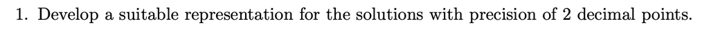

```python
import numpy as np

Kp_range = (2, 18)
Ti_range = (1.05, 9.42)
Td_range = (0.26, 2.37)

def random_individual():
    return np.array(
        [
            round(np.random.uniform(*Kp_range), 2),
            round(np.random.uniform(*Ti_range), 2),
            round(np.random.uniform(*Td_range), 2)
        ])
individual = random_individual()
print(individual)
```

```
[14.69  7.56  1.73]
```

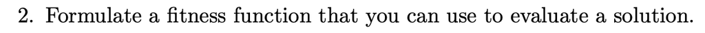

```python
import control as ctrl

def is_stable(system):
    poles = ctrl.pole(system)
    return np.all(np.real(poles) < 0)

def compute_step_metrics(t, y):
    y_final = y[-1]
    y_10 = y_final * 0.1
    y_90 = y_final * 0.9

    # Rise time
    try:
        idx_10 = np.where(y >= y_10)[0][0]
        idx_90 = np.where(y >= y_90)[0][0]
        t_r = t[idx_90] - t[idx_10]
    except IndexError:
        t_r = float('inf')

    # Settling time)
    within_2_percent = np.abs(y - y_final) <= 0.02 * y_final
    if np.any(within_2_percent):
        t_s_candidates = t[within_2_percent]
        t_s = t_s_candidates[0]
    else:
        t_s = float('inf')

    # Overshoot
    M_p = (np.max(y) - y_final) / y_final * 100 if y_final != 0 else float('inf')

    return t_r, t_s, M_p

def performance_metrics(Kp, Ti, Td):
    G = Kp * ctrl.TransferFunction([Ti * Td, Ti, 1], [Ti, 0])
    F = ctrl.TransferFunction([1], [1, 6, 11, 6, 0])
    sys = ctrl.feedback(ctrl.series(G, F), 1)

    # Check if the system is stable
    if not is_stable(sys):
        # Return a high penalty if the system is unstable
        return float('inf'), float('inf'), float('inf'), float('inf')

    t = np.linspace(0, 20, num=2001)
    t, y = ctrl.step_response(sys, t)

    # Calculate performance metrics
    ISE = np.sum((y - 1)**2)
    t_r, t_s, M_p = compute_step_metrics(t, y)

    # Handle NaN values by returning a high penalty
    if np.isnan(ISE) or np.isnan(t_r) or np.isnan(t_s) or np.isnan(M_p):
        return float('inf'), float('inf'), float('inf'), float('inf')

    return ISE, t_r, t_s, M_p
```

```python
def fitness_function(individual):
    ISE, t_r, t_s, M_p = performance_metrics(*individual)
    return ISE + t_r + t_s + M_p
```

```python
fitness_function(random_individual())
```

```
181.6316097165129
```

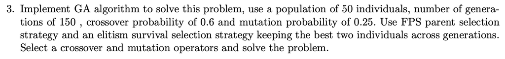

```python
# Define GA parameters
population_size = 50
num_generations = 150
crossover_prob = 0.6
mutation_prob = 0.25
def initialize_population(population_size):
    i = 0
    population = []
    fitnesses = []
    while i < population_size:
        individual = random_individual()
        fitness = fitness_function(individual)

        # Unstable solutions break the algoirthm, so we ignore them
        if not np.isinf(fitness):
            population.append(individual)
            fitnesses.append(fitness)
            i += 1
    population = np.array(population)
    fitnesses = np.array(fitnesses)
    return population, fitnesses
```

```python
print(initialize_population(2))
```

```
(array([[5.33, 3.09, 2.  ],
       [3.85, 8.35, 0.39]]), array([136.65282165, 276.72976659]))
```

```python
def select_parents(population, selection_probs):
    parents_idx = np.random.choice(population_size, size=2, p=selection_probs)
    return population[parents_idx[0]], population[parents_idx[1]]

def crossover(parent1, parent2):
    if np.random.random() < crossover_prob:
        # Single point crossover
        crossover_point = np.random.randint(1, 3)
        child1 = np.concatenate([parent1[:crossover_point], parent2[crossover_point:]])
        child2 = np.concatenate([parent2[:crossover_point], parent1[crossover_point:]])
        return child1, child2
    return parent1, parent2

def mutate(individual):
    if np.random.random() < mutation_prob:
        # Guassian mutation
        individual[0] = round(np.clip(individual[0] + np.random.normal(0, 1), *Kp_range), 2)
        individual[1] = round(np.clip(individual[1] + np.random.normal(0, 1), *Ti_range), 2)
        individual[2] = round(np.clip(individual[2] + np.random.normal(0, 1), *Td_range), 2)
    return individual
```

```python
from multiprocessing import Pool

def compute_fitnesses(population):
    with Pool() as pool:
        fitnesses = pool.map(fitness_function, [individual for individual in population])
    return np.array(fitnesses)
```

```python
def genetic_algorithm(population_size, num_generations):
    population, fitnesses = initialize_population(population_size)
    best_fitness_per_generation = []

    for generation in range(num_generations):
        print(f'Generation {generation + 1}/{num_generations}')
        if generation > 0:
            fitnesses = np.array([fitness_function(individual) for individual in population])

        best_fitness = min(fitnesses)
        best_fitness_per_generation.append(best_fitness)

        # Keep the best two individuals
        sorted_indices = np.argsort(fitnesses)
        next_population = population[sorted_indices[:2]]
        next_fitnesses = fitnesses[sorted_indices[:2]]

        # Generate new offspring
        selection_probs = fitnesses / np.sum(fitnesses)
        while len(next_population) < population_size:
            parent1, parent2 = select_parents(population, selection_probs)
            child1, child2 = crossover(parent1, parent2)

            child1 = mutate(child1)
            child2 = mutate(child2)

            fitness1 = fitness_function(child1)
            fitness2 = fitness_function(child2)

            # Unstable solutions break the algorithm, so we ignore them
            if not np.isinf(fitness1):
                next_population = np.vstack([next_population, child1])
                next_fitnesses = np.append(next_fitnesses, fitness1)
            if not np.isinf(fitness2):
                next_population = np.vstack([next_population, child2])
                next_fitnesses = np.append(next_fitnesses, fitness2)

        population = next_population[:population_size]

    best_individual = population[sorted_indices[0]]
    return best_individual, best_fitness_per_generation
```

```python
population_size = 50
num_generations = 150
crossover_prob = 0.6
mutation_prob = 0.25
best_individual, best_fitness_per_generation = genetic_algorithm(50, 5)
```

```
Generation 1/5
Generation 2/5
Generation 3/5
Generation 4/5
Generation 5/5
```

```python
import matplotlib.pyplot as plt

def plot_results(best_fitness_per_generation):
    plt.plot(best_fitness_per_generation)
    plt.xlabel("Generation")
    plt.ylabel("Best Fitness")
    plt.title("GA Optimization Progress")
    plt.show()
```

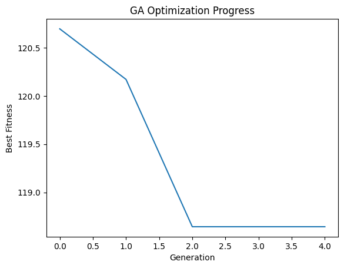

```python
plot_results(best_fitness_per_generation)
```

### Too Slow

- The algorithm appears to be working but it is really slow, so I moved the code over to q1.py so I could use Pool() and also let it run in seperate terminal session in the background
- In addition to using Pool() for multiprocess fitness evaluation, I also made the following changes to try and increase speed:
  - Reduced the simulation time and datapoints
  - Compute step metrics manually

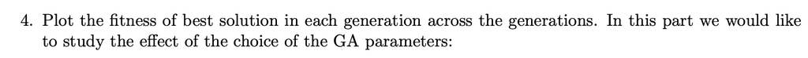

### 1.3 Output

#### Run Data

- Time taken: 1249.09s
- Best Individual: Kp=4.48 Ti=9.42 Td=2.37
- Best Fitness: 8.85

#### Plot

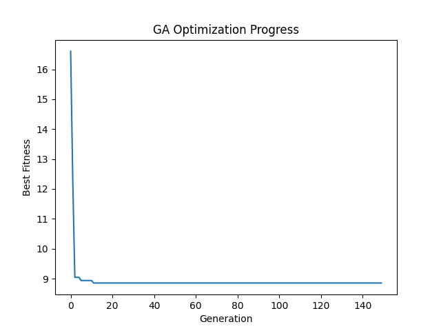

#### Summary of Results

- It looks like the algorithm converged pretty quickly onto a solution.
- This might mean that some of my hyper parameters are not well optimized or that my fitness function is not nuanced enough.
- It will be interesting to see what the result of the other experiments are.

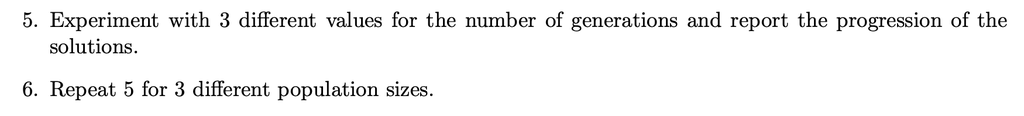

### Output for 1.5 and 1.6 Experiments

- Code for the experiemnts can be found in q1_5_6.py

#### Run Data

| Population Size | Number of Generations | Time Taken (s) | Best [Kp, Ti, Td] | Best Fitness |
| --- | --- | --- | --- | --- |
| 5 | 5 | 8.67 | [3.36, 6.67, 1.62] | 22.60 |
| 20 | 5 | 14.97 | [5.24, 6.64, 2.24] | 17.59 |
| 50 | 5 | 58.86 | [4.57, 8.25, 2.37] | 10.43 |
| 5 | 20 | 149.92 | [4.05, 9.41, 2.37] | 9.58 |
| 20 | 20 | 182.91 | [4.44, 9.42, 2.37] | 8.91 |
| 50 | 20 | 122.34 | [4.43, 9.42, 2.37] | 8.93 |
| 5 | 50 | 132.60 | [4.57, 8.67, 2.37] | 10.06 |
| 20 | 50 | 188.44 | [4.49, 9.42, 2.37] | 8.85 |
| 50 | 50 | 309.89 | [4.46, 9.42, 2.37] | 8.88 |

#### Plots

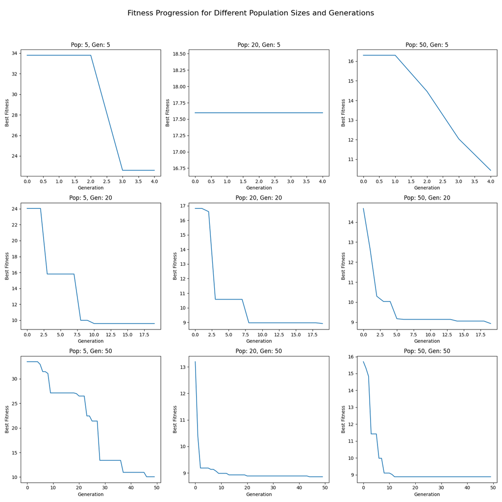

#### Summary of Results

- Larger populations generally lead to better solutions due to greater genetic diversity, which allows the algorithm to explore more of the solution space. However, this also increases computational time significantly.
- Running the algorithm for more generations typically improves the fitness results by allowing more refinement of solutions. However, the relationship isn't perfectly linear, as some configurations reach similar fitness values with fewer generations, particularly for larger populations.
- Lower population sizes and fewer generations are quicker but generally yield poorer solutions. High population sizes and generations provide better solutions but are computationally expensive.
- For a moderate balance between solution quality and computational time, a population size of 20 and around 20–50 generations appears to perform well.

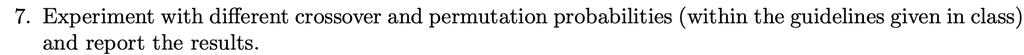

### 1.7 Output (Population=50, Generations=20)

#### Run Data

| Crossover Probability | Mutation Probability | Time Taken (s) | Best [Kp, Ti, Td] | Best Fitness |
| --- | --- | --- | --- | --- |
| 0.5 | 0.2 | 102.41 | [4.47, 9.42, 2.37] | 8.87 |
| 0.5 | 0.25 | 102.42 | [4.46, 9.42, 2.37] | 8.88 |
| 0.5 | 0.3 | 103.12 | [4.46, 9.42, 2.37] | 8.88 |
| 0.6 | 0.2 | 101.87 | [4.40, 9.42, 2.37] | 8.97 |
| 0.6 | 0.25 | 102.83 | [4.44, 9.42, 2.37] | 8.91 |
| 0.6 | 0.3 | 102.90 | [4.47, 9.42, 2.37] | 8.87 |
| 0.7 | 0.2 | 104.10 | [4.48, 9.42, 2.37] | 8.85 |
| 0.7 | 0.25 | 102.71 | [4.50, 9.42, 2.37] | 8.90 |
| 0.7 | 0.3 | 103.56 | [4.48, 9.42, 2.37] | 8.85 |

#### Plots

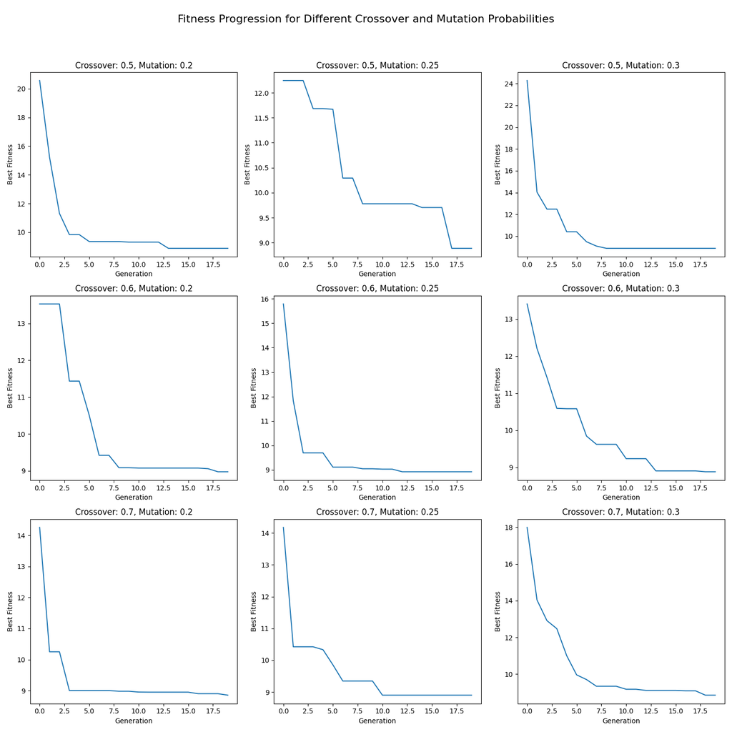

## Problem 2

### Problem Formulation

**Input Variables**:

- x, a vector in 10-dimensional space with each component xi in [-5.12, +5.12]
- Initial standard deviation for mutation in each dimension: sigma = 0.1 / (2 * sqrt(3))

**Objective Function**:

- Minimize the sphere function, defined as the sum of squares of each component in x.

**Constraint Functions**:

- Bound each component xi within the domain [-5.12, +5.12].

**Optimal Solution**:

- The solution is the vector x* that minimizes the sphere function.
- Strategy:
  - Simulate for 500 generations with adaptive mutation variance based on the convergence rate phi and test with three values for c.
  - Average results over 50 runs and plot the progression to find the c value that yields the lowest cost.

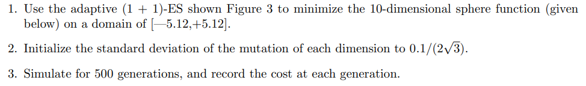

```python
import numpy as np

def sphere_function(x):
    return np.sum(x ** 2)
```

```python
def evolution_strategy(num_dimensions, num_generations, initial_sigma, bounds, c, G=50):
    x = np.random.uniform(bounds[0], bounds[1], num_dimensions)
    cost = sphere_function(x)
    cost_history = []
    sigma = initial_sigma
    success_count = 0

    for generation in range(num_generations):
        x_prime = x + np.random.normal(0, sigma, num_dimensions)
        x_prime = np.clip(x_prime, bounds[0], bounds[1])

        cost_prime = sphere_function(x_prime)
        if cost_prime < cost:
            x, cost = x_prime, cost_prime
            success_count += 1

        # Update sigma every G generations
        if (generation + 1) % G == 0:
            phi = success_count / G  # Proportion of successful mutations
            if phi < 1 / 5:
                sigma *= c ** 2
            else:
                sigma /= c ** 2

            success_count = 0

        cost_history.append(cost)

    return cost_history
```

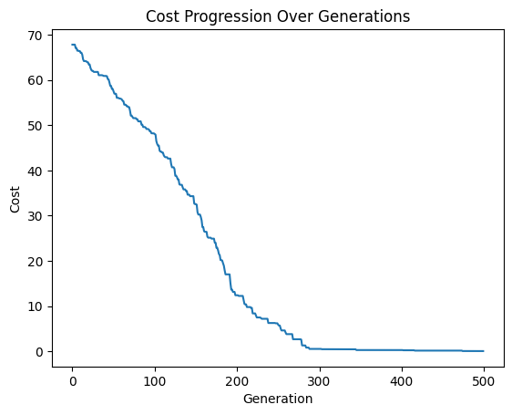

```python
num_dimensions = 10
num_generations = 500
initial_sigma = 0.1 / (2 * np.sqrt(3))
bounds = (-5.12, 5.12)
c = 0.817

cost_history = evolution_strategy(num_dimensions, num_generations, initial_sigma, bounds, c)

import matplotlib.pyplot as plt

plt.plot(cost_history)
plt.xlabel("Generation")
plt.ylabel("Cost")
plt.title("Cost Progression Over Generations")
plt.show()
```

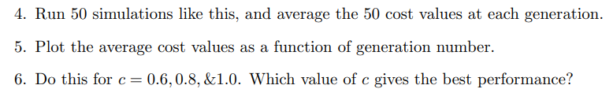

```python
def simulate_evolution(num_dimensions, num_generations, initial_sigma, bounds, c, G=10, num_simulations=50):
    all_cost_histories = []
    for _ in range(num_simulations):
        cost_history = evolution_strategy(num_dimensions, num_generations, initial_sigma, bounds, c, G)
        all_cost_histories.append(cost_history)

    average_cost_history = np.mean(all_cost_histories, axis=0)
    return average_cost_history
```

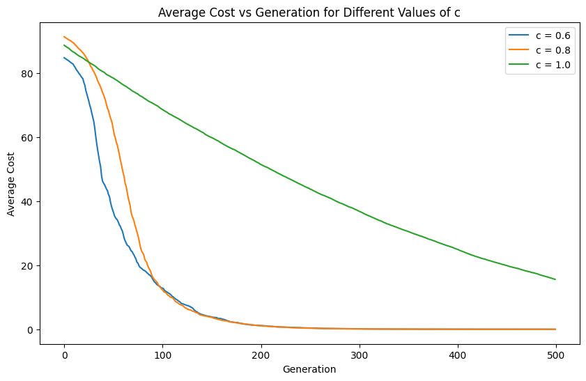

```
The best value of c is 0.8 with a final average cost of 0.0006918260634155178
```

```python
num_dimensions = 10
num_generations = 500
initial_sigma = 0.1 / (2 * np.sqrt(3))
bounds = (-5.12, 5.12)
c_values = [0.6, 0.8, 1.0]
G = 10
num_simulations = 50

average_cost_histories = {}
for c in c_values:
    average_cost_histories[c] = simulate_evolution(num_dimensions, num_generations, initial_sigma, bounds, c, G, num_simulations)

plt.figure(figsize=(10, 6))
for c, avg_cost in average_cost_histories.items():
    plt.plot(avg_cost, label=f'c = {c}')
plt.xlabel('Generation')
plt.ylabel('Average Cost')
plt.title('Average Cost vs Generation for Different Values of c')
plt.legend()
plt.show()

best_c = min(average_cost_histories, key=lambda k: average_cost_histories[k][-1])
print(f"The best value of c is {best_c} with a final average cost of {average_cost_histories[best_c][-1]}")
```

### Best Performance

- c = 0.6 has the fastest improvement initially but then intersects with c = 0.8.
- From then c = 0.6 and c = 0.8 produce very similar results, with c = 0.8 eeking out slightly better performance.
- From this we can say c = 0.8 delivers the best performance as it led to the lowest final average cost without and additionaly computational time.

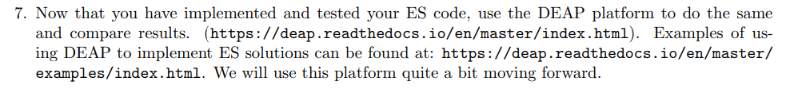

```python
from deap import base, creator, tools

def sphere_function_deap(individual):
    return np.sum(np.square(individual)),

def evolution_strategy_deap(num_dimensions, num_generations, initial_sigma, bounds, c, G=50):
    # Define problem and set up DEAP toolbox
    creator.create("FitnessMin", base.Fitness, weights=(-1.0,))
    creator.create("Individual", list, fitness=creator.FitnessMin)
    toolbox = base.Toolbox()

    # Attribute generator and individual
    toolbox.register("attr_float", np.random.uniform, bounds[0], bounds[1])
    toolbox.register("individual", tools.initRepeat, creator.Individual, toolbox.attr_float, num_dimensions)
    toolbox.register("evaluate", sphere_function_deap)
    toolbox.register("mutate", tools.mutGaussian, mu=0, sigma=initial_sigma, indpb=1.0)

    # Initialize population
    individual = toolbox.individual()
    cost = toolbox.evaluate(individual)[0]
    cost_history = []
    sigma = initial_sigma
    success_count = 0

    for generation in range(num_generations):
        mutant = creator.Individual(individual[:])
        toolbox.mutate(mutant, sigma=sigma)
        mutant = np.clip(mutant, bounds[0], bounds[1])

        cost_prime = toolbox.evaluate(mutant)[0]
        if cost_prime < cost:
            individual, cost = mutant, cost_prime
            success_count += 1

        if (generation + 1) % G == 0:
            phi = success_count / G
            if phi < 1 / 5:
                sigma *= c ** 2
            else:
                sigma /= c ** 2
            success_count = 0

        cost_history.append(cost)

    # Clean up DEAP classes
    del creator.FitnessMin
    del creator.Individual

    return cost_history
```

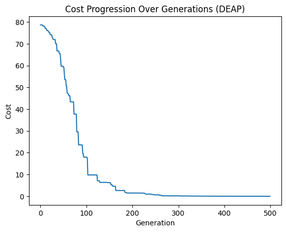

```python
num_dimensions = 10
num_generations = 500
initial_sigma = 0.1 / (2 * np.sqrt(3))
bounds = (-5.12, 5.12)
c = 0.817

cost_history = evolution_strategy_deap(num_dimensions, num_generations, initial_sigma, bounds, c, G)

plt.plot(cost_history)
plt.xlabel("Generation")
plt.ylabel("Cost")
plt.title("Cost Progression Over Generations (DEAP)")
plt.show()
```

```python
def simulate_evolution_deap(num_dimensions, num_generations, initial_sigma, bounds, c, G=50, num_simulations=50):
    all_cost_histories = []
    for _ in range(num_simulations):
        cost_history = evolution_strategy_deap(num_dimensions, num_generations, initial_sigma, bounds, c, G)
        all_cost_histories.append(cost_history)

    average_cost_history = np.mean(all_cost_histories, axis=0)
    return average_cost_history
```

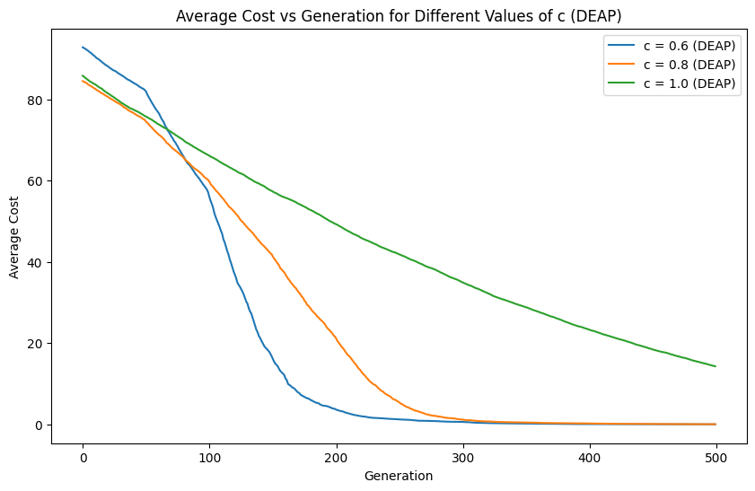

```
The best value of c in DEAP is 0.6 with a final average cost of 0.011148507488879474
```

```python
num_dimensions = 10
num_generations = 500
initial_sigma = 0.1 / (2 * np.sqrt(3))
bounds = (-5.12, 5.12)
c_values = [0.6, 0.8, 1.0]
G = 50
num_simulations = 50

average_cost_histories = {}
for c in c_values:
    average_cost_histories[c] = simulate_evolution_deap(num_dimensions, num_generations, initial_sigma, bounds, c, G, num_simulations)

plt.figure(figsize=(10, 6))
for c, avg_cost in average_cost_histories.items():
    plt.plot(avg_cost, label=f'c = {c} (DEAP)')
plt.xlabel('Generation')
plt.ylabel('Average Cost')
plt.title('Average Cost vs Generation for Different Values of c (DEAP)')
plt.legend()
plt.show()

best_c = min(average_cost_histories, key=lambda k: average_cost_histories[k][-1])
print(f"The best value of c in DEAP is {best_c} with a final average cost of {average_cost_histories[best_c][-1]}")
```

### Comparing Implementations

#### Stability

- The non-DEAP implementation demonstrated more consistent and smoother convergence across generations.
- The DEAP implementation showed similar trends but had slightly more fluctuations in the cost values, particularly for the lower c values.

## Problem 3

### Problem Formulation

**Input Variables**:

- Positions of 29 cities, defined by coordinates (xi, yi) for each city i.
- Parameters for ACO:
  - Pheromone persistence constant.
  - State transition control parameter.
  - Population size.
  - Online/offline pheromone update.

**Objective Function**:

- Minimize the total Euclidean distance of a complete tour that visits each city once and returns to the starting city.

**Constraint Functions**:

- Each city must be visited exactly once in the tour.
- The tour must be a closed loop, starting and ending at the same city.

**Optimal Solution**:

- A tour sequence that minimizes the total travel distance while adhering to constraints.
- Strategy:
  - Implement an ACO algorithm with varying parameters for pheromone persistence, transition control, population size, and pheromone updates.
  - Record and compare the results to identify parameter settings that yield the shortest tour length.

### Experimenting with NetLogo

- Increasing the population size can help overcome not having enough diffusion or too much evaporation to reach a far food source as the larger number of ants are more easily able to create complete pheromone train between the food and the nest.
- A higher diffusion rate allows a smaller number of ants to create a stable pheromone path to a further food source, but it also makes them faster at converging on a closer food source.
- Increasing the evaporation rate makes the ants more exploratory, they are much less likely to converge on a closer food source.
- Under all conditions, more ants increases the chance that a large number of ants will converge on a food source and consume it until it is gone.
- The diffusion and evaporation rates are how you can change the explotative vs explrative tendancies of the ants.
- More ants will converge quicker, but are more likly to to converge on a closer food source.

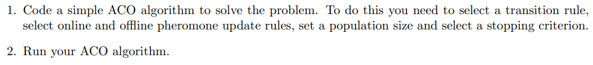

```python
def aco(num_ants, num_iterations, alpha, beta, evaporation_rate, num_cities, dist_matrix, online_update=True):
    pheromone = np.ones((num_cities, num_cities))
    best_path = None
    best_cost = float('inf')
    best_cost_history = []

    for _ in range(num_iterations):
        all_paths = []
        all_costs = []

        # Each ant constructs a path
        for _ in range(num_ants):
            path = [np.random.randint(0, num_cities - 1)]
            for _ in range(num_cities - 1):
                i = path[-1]
                probabilities = []
                for j in range(num_cities):
                    if j not in path:
                        pheromone_factor = pheromone[i][j] ** alpha
                        distance_factor = (1 / dist_matrix[i][j]) ** beta
                        probabilities.append(pheromone_factor * distance_factor)
                    else:
                        probabilities.append(0)
                probabilities = np.array(probabilities) / np.sum(probabilities)
                next_city = np.random.choice(range(num_cities), p=probabilities)
                path.append(next_city)

            # Calculate path cost
            cost = sum(dist_matrix[path[i], path[i + 1]] for i in range(num_cities - 1))
            cost += dist_matrix[path[-1], path[0]]  # Return to starting city

            all_paths.append(path)
            all_costs.append(cost)

            if cost < best_cost:
                best_path = path
                best_cost = cost

        best_cost_history.append(best_cost)

        # Pheromone evaporation
        pheromone *= (1 - evaporation_rate)

        if online_update:
            for path, cost in zip(all_paths, all_costs):
                for i in range(len(path) - 1):
                    pheromone[path[i], path[i + 1]] += 1 / cost
                pheromone[path[-1], path[0]] += 1 / cost



    return best_cost, best_path, best_cost_history
```

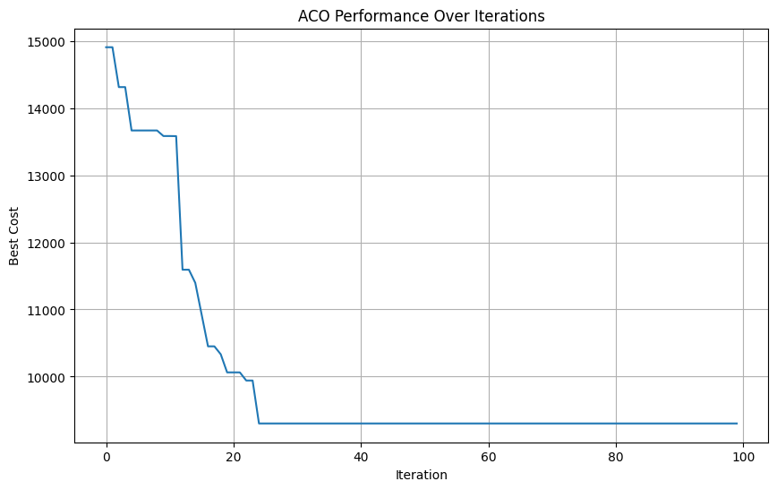

```python
cities = np.array([
    [1150, 1760], [630, 1660], [40, 2090], [750, 1100], [750, 2030],
    [1030, 2070], [1650, 650], [1490, 1630], [790, 2260], [710, 1310],
    [840, 550], [1170, 2300], [970, 1340], [510, 700], [750, 900],
    [1280, 1200], [230, 590], [460, 860], [1040, 950], [590, 1390],
    [830, 1770], [490, 500], [1840, 1240], [1260, 1500], [1280, 790],
    [490, 2130], [1460, 1420], [1260, 1910], [360, 1980]
])
num_cities = len(cities)
dist_matrix = np.sqrt(((cities[:, np.newaxis, :] - cities[np.newaxis, :, :]) ** 2).sum(axis=2))


best_cost, best_path, best_cost_history = aco(num_ants=30, num_iterations=100, alpha=1.0, beta=2.0, evaporation_rate=0.5, num_cities=num_cities, dist_matrix=dist_matrix)

plt.figure(figsize=(10, 6))
plt.plot(best_cost_history)
plt.xlabel("Iteration")
plt.ylabel("Best Cost")
plt.title("ACO Performance Over Iterations")
plt.grid(True)
plt.show()
```

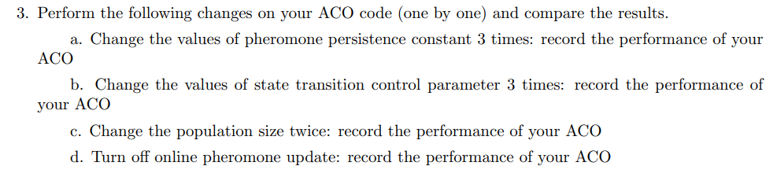

```
Evaporation Rate 0.1: Best Cost = 9773.173550754324
Execution Time: 3.27 seconds
Evaporation Rate 0.3: Best Cost = 9318.615782938083
Execution Time: 3.38 seconds
Evaporation Rate 0.7: Best Cost = 9318.615782938083
Execution Time: 3.31 seconds
Beta 1.0: Best Cost = 9506.370523551106
Execution Time: 3.27 seconds
Beta 2.5: Best Cost = 9195.224877317756
Execution Time: 3.40 seconds
Beta 3.0: Best Cost = 9413.068588300901
Execution Time: 3.46 seconds
Population Size 15: Best Cost = 9336.360966758353
Execution Time: 1.70 seconds
Population Size 60: Best Cost = 9318.615782938083
Execution Time: 6.48 seconds
Online Update Off: Best Cost = 11910.341571354267
Execution Time: 3.33 seconds
```

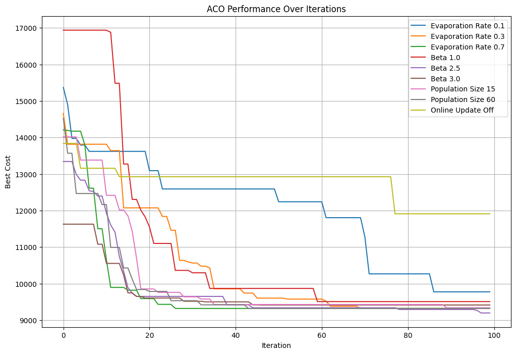

```python
import time

experiments = {
    "Evaporation Rate 0.1": {"evaporation_rate": 0.1},
    "Evaporation Rate 0.3": {"evaporation_rate": 0.3},
    "Evaporation Rate 0.7": {"evaporation_rate": 0.7},
    "Beta 1.0": {"beta": 1.0},
    "Beta 2.5": {"beta": 2.5},
    "Beta 3.0": {"beta": 3.0},
    "Population Size 15": {"num_ants": 15},
    "Population Size 60": {"num_ants": 60},
    "Online Update Off": {"online_update": False},
}

num_ants = 30
num_iterations = 100
alpha = 1.0
beta = 2.0
evaporation_rate = 0.5

plt.figure(figsize=(12, 8))
for label, params in experiments.items():
    # Merge default parameters with experiment-specific ones
    params = {**{"num_ants": num_ants, "num_iterations": num_iterations, "alpha": alpha,
                    "beta": beta, "evaporation_rate": evaporation_rate, "num_cities": num_cities,
                    "dist_matrix": dist_matrix, "online_update": True}, **params}
    start_time = time.time()
    best_cost, best_path, best_cost_history = aco(**params)
    end_time = time.time()
    plt.plot(best_cost_history, label=label)
    print(f"{label}: Best Cost = {best_cost}")
    print(f"Execution Time: {end_time - start_time:.2f} seconds")

plt.xlabel("Iteration")
plt.ylabel("Best Cost")
plt.title("ACO Performance Over Iterations")
plt.legend()
plt.grid(True)
plt.show()
```

#### Run Data

| Configuration | Best Cost | Execution Time (s) |
| --- | --- | --- |
| **Evaporation Rate** |  |  |
| 0.1 | 9773.17 | 3.27 |
| 0.3 | 9318.62 | 3.38 |
| 0.7 | 9318.62 | 3.31 |
| **Beta** |  |  |
| 1.0 | 9506.37 | 3.27 |
| 2.5 | 9195.22 | 3.40 |
| 3.0 | 9413.07 | 3.46 |
| **Population Size** |  |  |
| 15 | 9336.36 | 1.70 |
| 60 | 9318.62 | 6.48 |
| **Online Update** |  |  |
| Off | 11910.34 | 3.33 |

#### Summary of Results

- Higher beta values (especially 2.5) yielded better results, indicating the importance of distance in path selection.
- Lower evaporation rates slightly worsened the best cost but had similar execution times.
- Increasing the population size to 60 improved the solution but took significantly more time.
- Disabling online updates led to a much higher best cost, suggesting online updates are critical for optimization.